# Conflicts involving the Military of the Russian Federation

An overview

Thomas McKinney

June 18th 2023

# 1 tl;dr

- Russia is not the paragon of peace certain pundits in political discussions make it out to be.
- Putin has officially/unofficially been Commander in Chief of the Russian Armed Forces since 1999.
- Under his presidency Russia has involved itself in conflicts abroad.
- This includes conflicts, that involve some level of participation by the USA, NATO, and the EU.
- It also includes wars of aggression against sovereign Nations, and a track record of war crimes.

# 2 Version:

Last change: June 18th 2023

# 3 Introduction

Welcome to my very first R Notebook. I’ve only recently started playing around with exploratory Data Analysis in R. By inclination I’d describe myself more as a historian, than a (budding) Data Scientist. This notebook is a work in progress, so: I’d welcome any and all feedback. :-)

Certain voices in the political arena paint a picture of Russia as a peaceful state, that is the victim of US/NATO/EU aggression. In this Notebook I will not address the second of the statement, even though I do believe it is both wrong and very problematic. I am aiming to show however, that the first half of the statement is wrong. Looking at the involvement of the Russian Armed Forces shows, that Russia is a rather aggressive player on the world stage. And it does not take a very complicated analysis to show this.

# 4 Loading the Data

# 5 Timeline and Powers of Russian Presidents

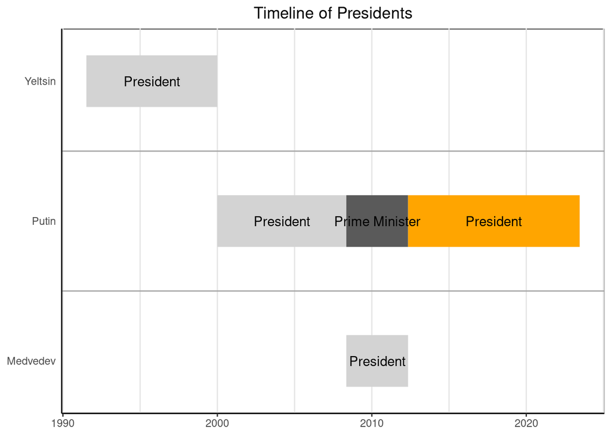

The Russian Constitution makes the President the [Supreme Commander in Chief of the Russian Armed Forces](https://www.departments.bucknell.edu/russian/const/ch4.html). The graph above is somewhat misleading, though. There was no real change of power during Medvedevs term of office as [president](https://www.britannica.com/question/Why-is-Vladimir-Putin-still-in-power). Medvedev was very much Putins [puppet](https://www.spiegel.de/international/world/the-puppet-president-medvedev-s-betrayal-of-russian-democracy-a-789767.html). De facto Putin has been calling the shots [since the late Yeltsin administration](https://inews.co.uk/news/world/when-did-vladimir-putin-come-to-power-how-long-he-has-been-russias-president-and-if-he-can-be-removed-1497977).

*Article 83:*

> The President of the Russian Federation shall: […] g) form and head the Security Council of the Russian Federation, the status of which is determined by federal law; h) endorse the military doctrine of the Russian Federation; i) form the staff of the President of the Russian Federation; […] k) appoint and dismiss the Supreme Command of the Armed Forces of the Russian Federation; […]

*Article 87:*

> 1. The President of the Russian Federation shall be the Supreme Commander-in-Chief of the Armed Forces of the Russian Federation.
> 2. In the event of aggression against the Russian Federation or an immediate threat thereof, the President of the Russian Federation shall introduce martial law on the territory of the Russian Federation or in areas thereof with immediate notification thereof of the Federation Council and the State Duma.

*Article 89*

> The President of the Russian Federation shall: […] b) award state decorations of the Russian Federation, confer honorary titles of the Russian Federation and top military ranks and top specialized titles; [c) grant pardon.[…]

# 6 Timeline and locations of the conflicts

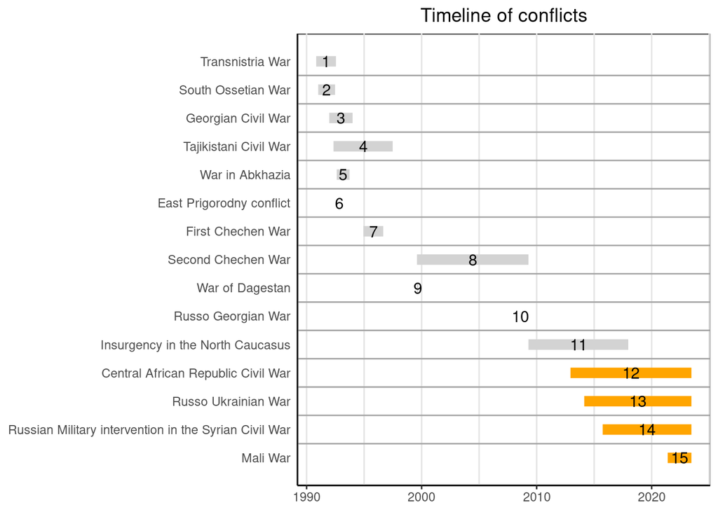

| conflict | start | end | country | color | number |
| --- | --- | --- | --- | --- | --- |
| Transnistria War | 1990-11-02 | 1992-07-21 | Moldova | #D3D3D3 | 1 |
| South Ossetian War | 1991-01-05 | 1992-06-24 | Georgia | #D3D3D3 | 2 |
| Georgian Civil War | 1991-12-22 | 1993-12-31 | Georgia | #D3D3D3 | 3 |
| Tajikistani Civil War | 1992-05-05 | 1997-06-27 | Tajikistan | #D3D3D3 | 4 |
| War in Abkhazia | 1992-08-14 | 1993-09-27 | Georgia | #D3D3D3 | 5 |
| East Prigorodny conflict | 1992-10-30 | 1992-11-06 | Russia | #D3D3D3 | 6 |
| First Chechen War | 1994-12-11 | 1996-08-31 | Russia | #D3D3D3 | 7 |
| Second Chechen War | 1999-08-07 | 2009-04-16 | Russia | #D3D3D3 | 8 |
| War of Dagestan | 1999-09-14 | 1999-08-07 | Russia | #D3D3D3 | 9 |
| Russo Georgian War | 2008-08-07 | 2008-08-12 | Russia | #D3D3D3 | 10 |

[output cut: 5 more lines]

First of all: Orange shows ongoing conflicts.

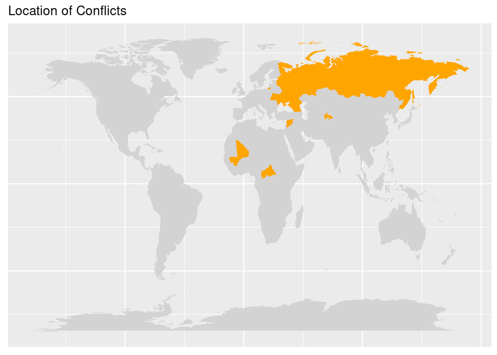

Quite a few conflicts happened on what is considered to be Russian territory. Hence Russia is shown here as a conflict location.

Every conflict from the [Second Chechen war](https://www.dw.com/en/opinion-russia-still-lives-in-the-shadow-of-the-chechen-war/a-50609732) on saw Putin as either Prime Minister or President. In his second term as president, Russia seems to have taken to engaging in conflicts that do not happen on former Soviet territory (Central African Republic, Syria, Mali) or on Russian soil. Russia also seems to be more willing to involve itself in conflicts, that see a participation of it’s political rivals (USA, NATO, EU). More importantly: Russia under Putin has been more than willing, to attack neighbouring states, that were seeking to align themselves with the West (Georgia, Ukraine). Russia also showed a tendency to commit war crimes, as both [Syria](https://www.theguardian.com/world/2020/mar/02/russia-committed-war-crimes-in-syria-finds-un-report) and the [Ukraine](https://www.ohchr.org/en/press-releases/2023/03/war-crimes-indiscriminate-attacks-infrastructure-systematic-and-widespread) show.

# 7 Bottom lines

- Putin has officially/unofficially been Commander in Chief of the Russian Armed Forces since 1999.
- Under his presidency Russia has involved itself in conflicts abroad.
- This includes conflicts, that involve some level of participation by the USA, NATO, and the EU.
- It also includes wars of aggression against sovereign Nations.

# 8 Conclusion

I believe, that it is fair to say, that Russia under Putin has been following a more aggressive course in foreign affairs. This undermines the narrative by some that Russia is a peaceful state, only seeking trade and cooperation. Much like everyone else, Russia is looking out for what it deems it’s national interests.